# Introduction to SC19088

## Solution 11.5

```r
root.114 <- root.115 <- 0
k<-c(4:25,100,500,1000)

# caculate the root in 11.4
f1=function(a,k){
  pt(sqrt(a^2*k/(k+1-a^2)),df=k)-pt(sqrt(a^2*(k-1)/(k-a^2)),df=k-1)
}
for (i in 1:25){
  root.114[i]=uniroot(f1,interval = c(-1,sqrt(k[i])-0.01),k=k[i])$root
}



# caculate the root in 11.5
ck=function(a,k){
  sqrt(a^2*k/(k+1-a^2))
}

# equation function in 11.5
f2=function(a,k){
  log(2)+lgamma(k/2)-0.5*log(pi*(k-1))-lgamma((k-1)/2)+log(integrate(function(u){(1+u^2/(k-1))^(-k/2)},0,ck(a,k-1))$value)-(log(2)+lgamma((k+1)/2)-0.5*log(pi*k)-lgamma(k/2)+log(integrate(function(u){(1+u^2/k)^(-(k+1)/2)},0,ck(a,k))$value))
}

for (i in 1:22){
  root.115[i]=uniroot(f2,interval = c(-1,root.114[i]+0.0001),k=k[i])$root
}

## Note: When k is large, the value range of the uniroot function must be fine, otherwise the two ends of the interval are likely to have the same number. So I set the upper bound separately for k = 100, 500, 1000
root.115[23]=uniroot(f2,interval = c(-1,9.98),k=k[23])$root
root.115[24]=uniroot(f2,interval = c(-1,sqrt(k[24])-0.03),k=k[24])$root
root.115[25]=uniroot(f2,interval = c(-1,sqrt(k[25]-1)),k=k[25])$root

root.114 #the result in 11.4
```

```
##  [1]  1.492104  1.533558  1.562746  1.584452  1.601189  1.614507  1.625383
##  [8]  1.634436  1.642028  1.648539  1.654179  1.659097  1.663434  1.667285
## [15]  1.670721  1.673818  1.676602  1.679153  1.681470  4.785832  4.888979
## [22]  4.990000  9.990000 22.350680 31.612777
```

```r
root.115 #the result in 11.5
```

```
##  [1]  1.492103  1.533559  1.562745  1.584429  1.601182  1.614517  1.625383
##  [8]  1.634409  1.642026  1.648540  1.654174  1.659096  1.663433  1.667283
## [15]  1.670724  1.673817  1.676614  1.679154  1.681471  1.683594  1.685547
## [22]  1.687348  1.720597 19.490100 31.421896
```

- We found that using the method of 11.4 to estimate k = 23,24,25 is very inaccurate, but the method of 11.5 lacks a good solution to this problem.

## Solution 3

```r
set.seed(12345)
p <- q <- 0.1
r=1-p-q
lf <- 0

LF=function(AA,BB,p,q){ #log-likelyhood function
  a=(28-AA)*log(2*p*r)+AA*log(p^2)+(24-BB)*log(2*q*r)+BB*log(q^2)+70*log(2*p*q)+2*41*log(r)
  return(a)
}

iter<-function(p,q){
  r<-1-p-q
  a<-2*28*(p^2)/(p^2+2*p*r)+2*p*r/(p^2+2*p*r)*28+70
  b<-2*24*(q^2)/(q^2+2*q*r)+2*q*r/(q^2+2*q*r)*24+70
  c<-2*41+2*p*r/(p^2+2*p*r)*28+2*q*r/(q^2+2*q*r)*24
  return(c(a/(a+b+c),b/(a+b+c)))
}

AA=sum(rbinom(28,1,(p^2/(p^2+2*p*r))))
BB=sum(rbinom(24,1,(q^2/(q^2+2*q*r))))
lf=LF(AA,BB,p,q)

for (i in 1:100){
  m=iter(p[i],q[i])
  p[i+1]=m[1];q[i+1]=m[2]
  AA=sum(rbinom(28,1,(p[i+1]^2/(p[i+1]^2+2*p[i+1]*r))))
  BB=sum(rbinom(24,1,(q[i+1]^2/(q[i+1]^2+2*q[i+1]*r))))
  lf[i+1]=LF(AA,BB,p[i+1],q[i+1])
  if(abs(p[i+1]-p[i])<=1e-4) break
}

p
```

```
## [1] 0.1000000 0.3056658 0.3242869 0.3268970 0.3272785 0.3273346
```

```r
q
```

```
## [1] 0.1000000 0.2926741 0.3080029 0.3100750 0.3103751 0.3104191
```

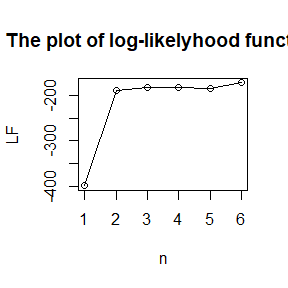

```r
plot(lf,type="o",xlab = "n",ylab = "LF",main="The plot of log-likelyhood function")
```

- In fact, I think the number of this topic is not strict. It is known that n (AB) = 70, n (OO) = 41, n = 163, which is also in line with HWE. It is difficult to find a suitable p, q for him Better fit this model.

## Homework in 20191213

## Question 1

- Use both for loops and lapply() to fit linear models to the mtcars using the formulas stored in this list: formulas <- list( mpg ~ disp, mpg ~ I(1 / disp), mpg ~ disp + wt, mpg ~ I(1 / disp) + wt )

## Solution 1

```r
formulas =list(mpg ~ disp,mpg ~ I(1 / disp),mpg ~ disp + wt,mpg ~ I(1 / disp) + wt)
# lapply() to fit linear models
lapply(formulas,lm,data=mtcars)
```

```
## [[1]]
##
## Call:
## FUN(formula = X[[i]], data = ..1)
##
## Coefficients:
## (Intercept)         disp
##    29.59985     -0.04122
##
##
## [[2]]
##
## Call:
## FUN(formula = X[[i]], data = ..1)
##
## Coefficients:
## (Intercept)    I(1/disp)
##       10.75      1557.67
##
##
## [[3]]
##
## Call:
## FUN(formula = X[[i]], data = ..1)
##
## Coefficients:
## (Intercept)         disp           wt
##    34.96055     -0.01772     -3.35083
##
##
## [[4]]
##
## Call:
## FUN(formula = X[[i]], data = ..1)
##
## Coefficients:
## (Intercept)    I(1/disp)           wt
##      19.024     1142.560       -1.798
```

```r
a<-list(NULL)
length(a)<-4
# for loop to fit linear models
for (i in 1:4){
  a[[i]]=lm(formula = formulas[[i]],data=mtcars)
}
a
```

```
## [[1]]
##
## Call:
## lm(formula = formulas[[i]], data = mtcars)
##
## Coefficients:
## (Intercept)         disp
##    29.59985     -0.04122
##
##
## [[2]]
##
## Call:
## lm(formula = formulas[[i]], data = mtcars)
##
## Coefficients:
## (Intercept)    I(1/disp)
##       10.75      1557.67
##
##
## [[3]]
##
## Call:
## lm(formula = formulas[[i]], data = mtcars)
##
## Coefficients:
## (Intercept)         disp           wt
##    34.96055     -0.01772     -3.35083
##
##
## [[4]]
##
## Call:
## lm(formula = formulas[[i]], data = mtcars)
##
## Coefficients:
## (Intercept)    I(1/disp)           wt
##      19.024     1142.560       -1.798
```

## Question 2

- Fit the model mpg ~ disp to each of the bootstrap replicates of mtcars in the list below by using a for loop and lapply(). Can you do it without an anonymous function? bootstraps <- lapply(1:10, function(i) { rows <- sample(1:nrow(mtcars), rep = TRUE) mtcars[rows, ] })

## Solution 2

```r
bootstraps <- lapply(1:10, function(i) {
rows <- sample(1:nrow(mtcars), rep = TRUE)
mtcars[rows, ]
})
lapply(bootstraps,lm,formula=mpg~disp)
```

```
## [[1]]
##
## Call:
## FUN(formula = ..1, data = X[[i]])
##
## Coefficients:
## (Intercept)         disp
##    29.20160     -0.04156
##
##
## [[2]]
##
## Call:
## FUN(formula = ..1, data = X[[i]])
##
## Coefficients:
## (Intercept)         disp
##    28.33457     -0.03741
##
##
## [[3]]
##
## Call:
## FUN(formula = ..1, data = X[[i]])
##
## Coefficients:
## (Intercept)         disp
##    29.88458     -0.03984
##
##
## [[4]]
##
## Call:
## FUN(formula = ..1, data = X[[i]])
##
## Coefficients:
## (Intercept)         disp
##    29.94355     -0.04208
##
##
```

[output cut: 43 more lines]

```
## FUN(formula = ..1, data = X[[i]])
##
## Coefficients:
## (Intercept)         disp
##    28.74840     -0.03908
##
##
## [[10]]
##
## Call:
## FUN(formula = ..1, data = X[[i]])
##
## Coefficients:
## (Intercept)         disp
##     29.2855      -0.0385
```

## Question 3

- For each model in the previous two exercises, extract R2 using the function below. rsq <- function(mod) summary(mod)$r.squared

## Solution 3

```r
# the function
rsq <- function(mod) summary(mod)$r.squared
formulas =list(mpg ~ disp,mpg ~ I(1 / disp),mpg ~ disp + wt,mpg ~ I(1 / disp) + wt)
# lapply() to fit linear models
a=lapply(formulas,lm,data=mtcars)
bootstraps <- lapply(1:10, function(i) {
rows <- sample(1:nrow(mtcars), rep = TRUE)
mtcars[rows, ]
})
b=lapply(bootstraps,lm,formula=mpg~disp)
# r^2 in Question 1
lapply(a, rsq)
```

```
## [[1]]
## [1] 0.7183433
##
## [[2]]
## [1] 0.8596865
##
## [[3]]
## [1] 0.7809306
##
## [[4]]
## [1] 0.8838038
```

```r
# r^2 in Question 2
lapply(b, rsq)
```

```
## [[1]]
## [1] 0.7807689
##
## [[2]]
## [1] 0.6643146
##
## [[3]]
## [1] 0.7457081
##
## [[4]]
## [1] 0.7637815
##
## [[5]]
## [1] 0.8145855
##
## [[6]]
## [1] 0.6971955
##
## [[7]]
## [1] 0.8031412
##
## [[8]]
## [1] 0.8037138
##
## [[9]]
## [1] 0.7397875
##
## [[10]]
## [1] 0.700006
```

## Question 4

- The following code simulates the performance of a t-test for non-normal data. Use sapply() and an anonymous function to extract the p-value from every trial. trials <- replicate( 100, t.test(rpois(10, 10), rpois(7, 10)), simplify = FALSE ) Extra challenge: get rid of the anonymous function by using [[ directly.

## Solution 4

```r
trials <- replicate(100,t.test(rpois(10, 10), rpois(7, 10)),simplify = FALSE)
sapply(trials, '[[', 3)
```

```
##   [1] 0.10599611 0.03711881 0.77183098 0.02347388 0.55142969 0.96544609
##   [7] 0.60425475 0.54001778 0.07009208 0.62865611 0.13411398 0.16487915
##  [13] 0.13402049 0.98710840 0.50764079 0.03341741 0.50613058 0.73978891
##  [19] 0.60907458 0.43579974 0.16792036 0.04500086 0.47322209 0.08892749
##  [25] 0.32674030 0.26925152 0.73536908 0.33504031 0.46619458 0.20936246
##  [31] 0.29723196 0.48056112 0.97382001 0.01397090 0.01891176 0.24466680
##  [37] 0.05289983 0.61005067 0.26282882 0.35789687 0.43812334 0.80374651
##  [43] 0.89207977 0.79875887 0.13296491 0.67252696 0.04597314 0.74735569
##  [49] 0.68063373 0.52343998 0.72020895 0.25883715 0.09622342 0.37684525
##  [55] 0.24836912 0.79693926 0.45699557 0.88475421 0.65811655 0.75295695
##  [61] 0.46395950 0.47361626 0.37915832 0.47370144 0.48530956 0.93288660
##  [67] 0.47696515 0.21400849 0.44347594 0.64331581 0.30614998 0.20914298
##  [73] 0.98700790 0.49716423 0.18916520 0.18851628 0.29275205 0.66549287
##  [79] 0.90660666 0.36387514 0.88141847 0.95613844 0.04984235 0.83483844
##  [85] 0.41149077 0.65999998 0.21832446 0.59156447 0.37084773 0.49619350
##  [91] 0.98593668 0.16167999 0.84588653 0.06291973 0.07935894 0.98060347
##  [97] 0.48500500 0.87112397 0.73094899 0.81477829
```

## Question 5

- Implement mcsapply(), a multicore version of sapply(). Can you implement mcvapply(), a parallel version of vapply()?Why or why not?

## Solution 5

```r
# We can use the function parSapply() to do this work.
library(parallel)
cores <- detectCores()
cl <- makePSOCKcluster(cores-1)
#parSapply(cl = NULL, X, FUN, ..., simplify = TRUE,          USE.NAMES = TRUE, chunk.size = NULL)
parSapply(cl,1:10,FUN=sin)
```

```
##  [1]  0.8414710  0.9092974  0.1411200 -0.7568025 -0.9589243 -0.2794155
##  [7]  0.6569866  0.9893582  0.4121185 -0.5440211
```

## Homework in 20191220

## Question

- You have already written an R function for Exercise 9.4 (page 277, Statistical Computing with R). Rewrite an Rcpp function for the same task.
- Compare the generated random numbers by the two functions using qqplot.
- Campare the computation time of the two functions with microbenchmark.
- Comments your results.

## Solution

```r
library(Rcpp)
library(microbenchmark)
set.seed(12345)

# Use Rcpp to solve the problem
cppFunction('List Metropolis(double sigma, double x0 , int N){
  NumericVector x(N);
  NumericVector u=runif(N);
    x[0]=x0;
    int k=0;
  for(int i = 1; i < N; ++i) {
        double y=rnorm(1,x[i-1],sigma)[0];
      double p=exp(-abs(y))/exp(-abs(x[i-1]));
        if(u[i-1]<= p) {x[i]=y;}
      else{x[i]=x[i-1]; k=k+1; }
    }
  List L=List::create(Named("x")=x,
                      Named("k")=k);
  return L;
}')

N = 2000
sigma = c(.05, .5, 2, 16)
x0 = 25

cpp1=Metropolis(sigma[1],x0,N)
cpp2=Metropolis(sigma[2],x0,N)
cpp3=Metropolis(sigma[3],x0,N)
cpp4=Metropolis(sigma[4],x0,N)

#number of candidate points rejected
Rej = cbind(cpp1$k, cpp2$k, cpp3$k, cpp4$k)
Acc = round((N-Rej)/N,4)
rownames(Acc) = "Accept rates"
colnames(Acc) = paste("sigma",sigma)
knitr::kable(Acc)
```

|  | sigma 0.05 | sigma 0.5 | sigma 2 | sigma 16 |
| --- | --- | --- | --- | --- |
| Accept rates | 0.985 | 0.8615 | 0.573 | 0.114 |

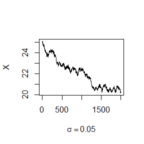

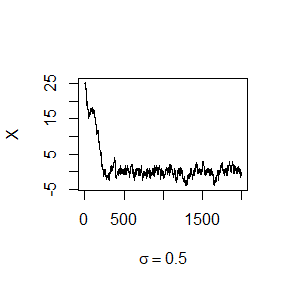

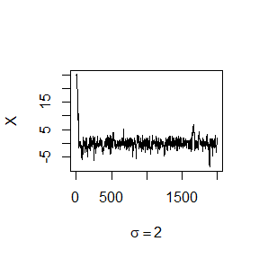

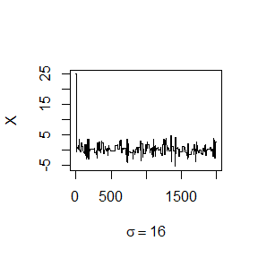

```r
#plot
 #display 4 graphs together
    rw = cbind(cpp1$x, cpp2$x, cpp3$x,  cpp4$x)
    for (j in 1:4) {
        plot(rw[,j], type="l",
             xlab=bquote(sigma == .(round(sigma[j],3))),
             ylab="X", ylim=range(rw[,j]))
    }
```

```r
# Use R to solve the problem
lap_f = function(x) exp(-abs(x))
rw.Metropolis = function(sigma, x0, N){
 x = numeric(N)
 x[1] = x0
 u = runif(N)
 k = 0
 for (i in 2:N) {
  y = rnorm(1, x[i-1], sigma)
  if (u[i] <= (lap_f(y) / lap_f(x[i-1]))) x[i] = y
  else {
  x[i] = x[i-1]
  k = k+1
  }
 }
 return(list(x = x, k = k))
}

rw1 = rw.Metropolis(sigma[1],x0,N)
rw2 = rw.Metropolis(sigma[2],x0,N)
rw3 = rw.Metropolis(sigma[3],x0,N)
rw4 = rw.Metropolis(sigma[4],x0,N)

#number of candidate points rejected
Rej = cbind(rw1$k, rw2$k, rw3$k, rw4$k)
Acc = round((N-Rej)/N,4)
rownames(Acc) = "Accept rates"
colnames(Acc) = paste("sigma",sigma)
knitr::kable(Acc)
```

|  | sigma 0.05 | sigma 0.5 | sigma 2 | sigma 16 |
| --- | --- | --- | --- | --- |
| Accept rates | 0.982 | 0.827 | 0.543 | 0.113 |

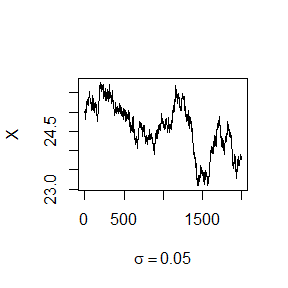

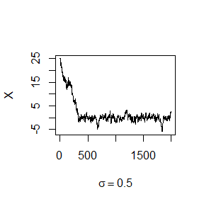

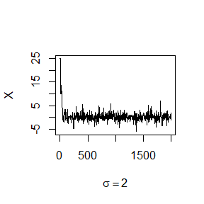

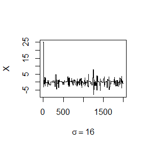

```r
#plot
  #display 4 graphs together
    rw = cbind(rw1$x, rw2$x, rw3$x,  rw4$x)
    for (j in 1:4) {
        plot(rw[,j], type="l",
             xlab=bquote(sigma == .(round(sigma[j],3))),
             ylab="X", ylim=range(rw[,j]))
    }
```

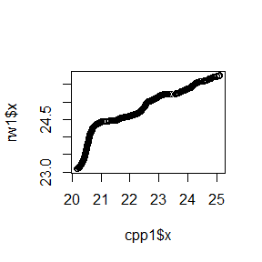

```r
## Compare the generated random numbers by the two functions using qqplot.
## Acturally, I don't know what this problem means.I compared x in two methods,but it is doesn't make sense.


qqplot(cpp1$x,rw1$x)
```

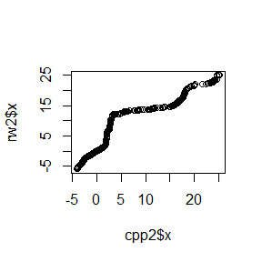

```r
qqplot(cpp2$x,rw2$x)
```

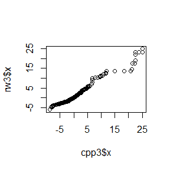

```r
qqplot(cpp3$x,rw3$x)
```

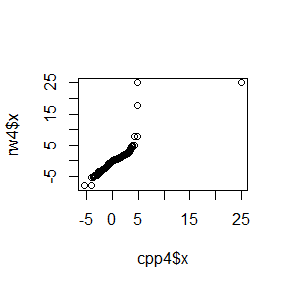

```r
qqplot(cpp4$x,rw4$x)
```

```r
## Campare the computation time of the two functions with microbenchmark.
ts1=microbenchmark(rpp=Metropolis(sigma[1],x0,N),r=rw.Metropolis(sigma[1],x0,N))
summary(ts1)[,c(1,3,5,6)]
```

```
##   expr      lq  median     uq
## 1  rpp  306.65  311.15  320.9
## 2    r 4621.85 4716.85 5118.3
```

```r
ts2=microbenchmark(rpp=Metropolis(sigma[2],x0,N),r=rw.Metropolis(sigma[2],x0,N))
summary(ts2)[,c(1,3,5,6)]
```

```
##   expr      lq median     uq
## 1  rpp  242.95  246.9  253.4
## 2    r 4694.05 4727.3 4800.6
```

```r
ts3=microbenchmark(rpp=Metropolis(sigma[3],x0,N),r=rw.Metropolis(sigma[3],x0,N))
summary(ts3)[,c(1,3,5,6)]
```

```
##   expr      lq  median      uq
## 1  rpp  260.15  267.60  277.00
## 2    r 4712.65 4834.75 5047.85
```

```r
ts4=microbenchmark(rpp=Metropolis(sigma[4],x0,N),r=rw.Metropolis(sigma[4],x0,N))
summary(ts4)[,c(1,3,5,6)]
```

```
##   expr      lq  median      uq
## 1  rpp  271.10  278.20  290.35
## 2    r 4804.55 4925.05 5077.45
```

- From the compared time we can find that cpp methods is much better than R methods.It is significante that Rcpp can improve the computational efficency.